# OECD analysis

Antonio Collante Caro (111 227 429)

26 March, 2020

# 1 OECD - Intergovernmental Economic Organisation

## 1.1 Upload data from OECD website

OECD website allows people to download cvs files based on the existing initiatives per country. So, I donwloaded each file corresponding to every country and saved them into the data folder in the R environment to be later processed creating an only one data structure. I created an *import function* that helps to combine all data within the files into a unique dataset called *data.set.imported*

## 1.2 Some statistics regarding the dataset created after the import

- *Observations* :

```
## # A tibble: 1 x 1
##   count
##   <int>
## 1   636
```

- *Following the three (3) first rows of the dataset without any Exploration Data Analysis (EDA):*

```
## # A tibble: 3 x 27
##   `Policy initiat~ `English name` `Original name(~ Acronym Description
##   <chr>            <chr>          <chr>            <chr>   <chr>
## 1 http://stip.oec~ NATIONAL COMM~ Comité Nacional~ CECTE   The CECTE ~
## 2 http://stip.oec~ IBM WATSON AI~ Pilot test of t~ WATSON  Argentina ~
## 3 http://stip.oec~ ARTIFICIAL IN~ Plan Nacional d~ <NA>    The Strate~
## # ... with 22 more variables: `Start date` <dbl>, `End date` <dbl>,
## #   `Budget amount\r(in local currency)` <dbl>, Background <chr>,
## #   `Objective(s)` <chr>, `Responsible organisation(s)` <chr>, `Public
## #   access URL` <chr>, `Is evaluated ?` <lgl>, `Evaluation URL` <lgl>,
## #   `Yearly budget range` <chr>, Country <chr>, `Theme area(s)` <chr>,
## #   `Theme(s)` <chr>, `Target group type(s)` <chr>, `Target
## #   group(s)` <chr>, `Policy instrument ID` <chr>, `Policy instrument type
## #   category` <chr>, `Policy instrument type` <chr>, `Policy instrument
## #   name` <chr>, `Policy instrument description(s)` <chr>, `Policy
## #   instrument note(s)` <lgl>, `Policy instrument mini-field(s)` <chr>
```

- *Daset columns* :

I have noticed that after the import that the following columns were loaded as:  
*Start date* : double  
*End date* : double  
*Evaluation URL* : logical  
*Policy instrument note(s)* : logical

I think these columns must be switched to a different data type during the EDA.

```
## $`Policy initiative ID`
## [1] "character"
##
## $`English name`
## [1] "character"
##
## $`Original name(s)`
## [1] "character"
##
## $Acronym
## [1] "character"
##
## $Description
## [1] "character"
##
## $`Start date`
## [1] "double"
##
## $`End date`
## [1] "double"
##
## $`Budget amount\r(in local currency)`
## [1] "double"
##
## $Background
## [1] "character"
##
## $`Objective(s)`
## [1] "character"
##
## $`Responsible organisation(s)`
## [1] "character"
##
## $`Public access URL`
## [1] "character"
##
## $`Is evaluated ?`
## [1] "logical"
##
## $`Evaluation URL`
```

[output cut: 25 more lines]

```
##
## $`Policy instrument type`
## [1] "character"
##
## $`Policy instrument name`
## [1] "character"
##
## $`Policy instrument description(s)`
## [1] "character"
##
## $`Policy instrument note(s)`
## [1] "logical"
##
## $`Policy instrument mini-field(s)`
## [1] "character"
```

# 2 Exploratory Data Analysis - EDA

## 2.1 Data analysis and manipulation

After analysing the dataset, I reached the conclusion that the following columns should pay a particular attention regarding the NA values and format:  
As example, I will show an observation for each column in the dataset.

- `_Policy initiative ID`_: http://stip.oecd.org/2019/data/policyInitiatives/15065. I decided to remove the “http://stip.oecd.org/2019/data/policyInitiatives/” string from the observations and leave the numeric value only since the link(s) produce(s) an error once we tried to open it. The *Policy initiative ID* after the transformation: 15065
- `_English name`_: NATIONAL COMMITTEE OF ETHICS IN SCIENCE AND TECHNOLOGY. and **number of NA’s values : 0**. I decided not to apply any action on this column - I keep the observations as they are from the import.
- `_Original name(s)`_: Comité Nacional de Etica en Ciencia y Tecnología. and **number of NA’s values : 285**. I decided not to apply any action on this column - I keep the observations as they are from the import.
- `_Acronym`_: CECTE. and **number of NA’s values : 448**. I decided not to apply any action on this column - I keep the observations as they are from the import.
- `_Description`_:The CECTE is a pluralistic and independent space for the critical and interdisciplinary analysis of topics related to the ethics of research in all areas of science and new technologies. It was created in April 2001 through Resolution 004/2001 of the Secretariat of Science, Technology and Productive Innovation and since 2007 it operates within the scope of the Ministry of Science, Technology and Productive Innovation.. and **number of NA’s values : 6**. I decided not to apply any action on this column - I keep the observations as they are from the import.
- `_Start Date`_:2001. and **number of NA’s values : 15**. The following is the list of NA’s values:

```
## # A tibble: 15 x 3
##    `Policy initiative ID` `Start date` Country
##    <chr>                         <dbl> <chr>
##  1 26500                            NA Bulgaria
##  2 26484                            NA Cyprus
##  3 26496                            NA Spain
##  4 26505                            NA Estonia
##  5 26451                            NA France
##  6 26501                            NA Croatia
##  7 26459                            NA Hungary
##  8 26495                            NA Hungary
##  9 24667                            NA India
## 10 16332                            NA Morocco
## 11 16699                            NA Morocco
## 12 24325                            NA Morocco
## 13 24268                            NA Poland
## 14 26017                            NA Saudi Arabia
## 15 25434                            NA United States
```

My approach to solve this issue of NA’s values for the Start_Date column is to run a search by country and assign the *MODE* of start_date to the corresponding NA value of the countries in list shown above. In the case, there is not more observations regarding to a country in the list, I would assign the *MODE* of the entire population to the NA value of that country/observation.

```
## # A tibble: 0 x 3
## # ... with 3 variables: `Policy initiative ID` <chr>, `Start date` <dbl>,
## #   Country <chr>
```

- *`Start date`*:2001. and **number of NA’s values : 0**. After applying a rule to avoid NA’s values
- *`End date`*:NA. and **number of NA’s values : 439**. I decided not to apply any action on this column - I keep the observations as they are from the import.
- *`Budget amount\r(in local currency)`*:NA. and **number of NA’s values : 631**. I decided not to apply any action on this column - I keep the observations as they are from the import.
- *`Background`*:NA. and **number of NA’s values : 228**. I decided not to apply any action on this column - I keep the observations as they are from the import.
- *`Objective(s)`*:To execute actions tending to incorporate the ethical dimension in the institutions of science and technology. To collaborate with science and technology institutions and universities to incorporate ethical principles into the protocols of research projects across all disciplines. To ensure the interoperability of the rules related to the purposes of the Committee and those that govern the Mercosur. To support, at your request, the initiatives of the scientific societies in the elaboration of codes of ethics, the creation and coordination of local committees, and ethics institutions. To contribute to university education with the development of ethical training programs for students with a vocation for scientific and technological research. To promote training in the application of ethical principles in the tasks of management and evaluation in national and provincial agencies of the sector.. and **number of NA’s values : 12**. I decided not to apply any action on this column - I keep the observations as they are from the import.
- *`Responsible organisation(s)`*:Ministry of Science, Technology and Productive Innovation (MINCYT;Ministerio de Ciencia, Tecnología e Innovación Productiva). and **number of NA’s values : 19**. I decided not to apply any action on this column - I keep the observations as they are from the import.
- *`Public access URL`*:NA. and **number of NA’s values : 118**. I decided not to apply any action on this column - I keep the observations as they are from the import.
- *`Is evaluated ?`*:FALSE. and **number of NA’s values : 0**. I decided not to apply any action on this column - I keep the observations as they are from the import.
- *`Evaluation URL`*:NA. and **number of NA’s values : 636**. I decided not to apply any action on this column - I keep the observations as they are from the import.
- *`Yearly budget range`*:Not applicable. and **number of NA’s values : 63**.List of NA’s for the column Yearly budget range:

```
## # A tibble: 63 x 3
##    `Policy initiative ID` `Yearly budget range` Country
##    <chr>                  <chr>                 <chr>
##  1 26500                  <NA>                  Bulgaria
##  2 24562                  <NA>                  Canada
##  3 24661                  <NA>                  Canada
##  4 24426                  <NA>                  China
##  5 24251                  <NA>                  Colombia
##  6 24251                  <NA>                  Colombia
##  7 26448                  <NA>                  Colombia
##  8 26448                  <NA>                  Colombia
##  9 26484                  <NA>                  Cyprus
## 10 26502                  <NA>                  Germany
## # ... with 53 more rows
```

```
## # A tibble: 0 x 3
## # ... with 3 variables: `Policy initiative ID` <chr>, `Yearly budget
## #   range` <chr>, Country <chr>
```

- *`Country`*:Argentina. and **number of NA’s values : 0**. I decided not to apply any action on this column - I keep the observations as they are from the import.
- *`Theme area(s)`*:Emerging trends in STI policy|Public research system|Research and innovation for society. and **number of NA’s values : 0**. I decided not to apply any action on this column - I keep the observations as they are from the import.
- *`Theme(s)`*:Ethics of emerging technologies|Multi-stakeholder engagement|Research integrity and reproducibility. and **number of NA’s values : 0**. I decided not to apply any action on this column - I keep the observations as they are from the import.
- *`Target group type(s)`*:Firms by age|Firms by size|Intermediaries|Researchers, students and teachers|Social groups especially emphasised. and **number of NA’s values : 15**. List of NA’s for the column Target Group type(s):

```
## # A tibble: 15 x 3
##    `Policy initiative ID` `Target group type(s)` Country
##    <chr>                  <chr>                  <chr>
##  1 26500                  <NA>                   Bulgaria
##  2 24426                  <NA>                   China
##  3 26502                  <NA>                   Germany
##  4 26496                  <NA>                   Spain
##  5 24790                  <NA>                   France
##  6 24319                  <NA>                   United Kingdom
##  7 26425                  <NA>                   United Kingdom
##  8 26442                  <NA>                   United Kingdom
##  9 26501                  <NA>                   Croatia
## 10 26459                  <NA>                   Hungary
## 11 24667                  <NA>                   India
## 12 24268                  <NA>                   Poland
## 13 26455                  <NA>                   Russian Federation
## 14 26460                  <NA>                   Slovenia
## 15 26337                  <NA>                   Thailand
```

I will apply the same principle as I did before for start_date to fix the NA’s value for the *Target Group Type(s), Target group(s), Policy instrument type category and Policy instrument type*. I will apply or assign the *MODE*.

```
## # A tibble: 0 x 3
## # ... with 3 variables: `Policy initiative ID` <chr>, `Target group
## #   type(s)` <chr>, Country <chr>
```

- *`Target group(s)`*:Academic societies / academies|Civil society|Established researchers|Firms of any age|Firms of any size. and **number of NA’s values : 15**.

List of NA’s for the column Target Group(s):

```
## # A tibble: 15 x 3
##    `Policy initiative ID` `Target group(s)` Country
##    <chr>                  <chr>             <chr>
##  1 26500                  <NA>              Bulgaria
##  2 24426                  <NA>              China
##  3 26502                  <NA>              Germany
##  4 26496                  <NA>              Spain
##  5 24790                  <NA>              France
##  6 24319                  <NA>              United Kingdom
##  7 26425                  <NA>              United Kingdom
##  8 26442                  <NA>              United Kingdom
##  9 26501                  <NA>              Croatia
## 10 26459                  <NA>              Hungary
## 11 24667                  <NA>              India
## 12 24268                  <NA>              Poland
## 13 26455                  <NA>              Russian Federation
## 14 26460                  <NA>              Slovenia
## 15 26337                  <NA>              Thailand
```

After applying the *Mode* to the NA’s in the Target group(s)

```
## # A tibble: 0 x 3
## # ... with 3 variables: `Policy initiative ID` <chr>, `Target
## #   group(s)` <chr>, Country <chr>
```

- *`Policy instrument ID`*:http://stip.oecd.org/2019/data/policyInitiatives/15065/instrument/12906. and **number of NA’s values : 0**. I decided to remove the “http://stip.oecd.org/2019/data/policyInitiatives/15065/instrument/” string from the observations and leave the numeric value only since the link(s) produce(s) an error once we tried to open it. The *Policy instrument ID* after the transformation: 12906
- *`Policy instrument type category`*:Governance. and **number of NA’s values : 10**.List of NA’s for the column Policy instrument type category:

```
## # A tibble: 10 x 3
##    `Policy initiative ID` `Policy instrument type category` Country
##    <chr>                  <chr>                             <chr>
##  1 26454                  <NA>                              Australia
##  2 26449                  <NA>                              Colombia
##  3 26496                  <NA>                              Spain
##  4 26332                  <NA>                              France
##  5 26457                  <NA>                              United Kingdom
##  6 26297                  <NA>                              Iceland
##  7 26479                  <NA>                              Japan
##  8 26335                  <NA>                              Lithuania
##  9 26450                  <NA>                              Luxembourg
## 10 26383                  <NA>                              Singapore
```

After applying the *Mode* to the NA’s in the Policy instrument type category

```
## # A tibble: 0 x 3
## # ... with 3 variables: `Policy initiative ID` <chr>, `Policy instrument
## #   type category` <chr>, Country <chr>
```

- *`Policy instrument type`*:Policy intelligence (e.g. evaluations, benchmarking and forecasts). and **number of NA’s values : 10**. List of NA’s for the column Policy instrument type :

```
## # A tibble: 10 x 3
##    `Policy initiative ID` `Policy instrument type` Country
##    <chr>                  <chr>                    <chr>
##  1 26454                  <NA>                     Australia
##  2 26449                  <NA>                     Colombia
##  3 26496                  <NA>                     Spain
##  4 26332                  <NA>                     France
##  5 26457                  <NA>                     United Kingdom
##  6 26297                  <NA>                     Iceland
##  7 26479                  <NA>                     Japan
##  8 26335                  <NA>                     Lithuania
##  9 26450                  <NA>                     Luxembourg
## 10 26383                  <NA>                     Singapore
```

After applying the *Mode* to the NA’s in the Policy instrument type:

```
## # A tibble: 0 x 3
## # ... with 3 variables: `Policy initiative ID` <chr>, `Policy instrument
## #   type` <chr>, Country <chr>
```

- *`Policy instrument name`*:NA. and **number of NA’s values : 447**. I decided not to apply any action on this column - I keep the observations as they are from the import.
- *`Policy instrument description(s)`*:NA. and **number of NA’s values : 443**. I decided not to apply any action on this column - I keep the observations as they are from the import.
- *`Policy instrument note(s)`*:NA. and **number of NA’s values : 636**. I decided not to apply any action on this column - I keep the observations as they are from the import.
- *`Policy instrument mini-field(s)`*:Provides input to: Policy objective formulation|Study performed by: Public administration, Public research institute, Academia|Type of information: Evaluations, Reviews. and **number of NA’s values : 108**. I decided not to apply any action on this column - I keep the observations as they are from the import.

## 2.2 Data set transformations

I decided to create a new dataset having some data transformations done and the columns renamed in order to facilitate the data manipulation.

```
## $v1
## [1] "character"
##
## $v2
## [1] "character"
##
## $v3
## [1] "character"
##
## $v4
## [1] "integer"
##
## $v5
## [1] "integer"
##
## $v6
## [1] "double"
##
## $v7
## [1] "character"
##
## $v8
## [1] "character"
##
## $v9
## [1] "integer"
##
## $v10
## [1] "integer"
##
## $v11
## [1] "character"
##
## $v12
## [1] "character"
##
## $v13
## [1] "integer"
##
## $v14
## [1] "integer"
##
## $v15
## [1] "integer"
##
## $v16
## [1] "integer"
##
## $v17
## [1] "character"
##
## $v18
## [1] "integer"
##
## $v19
## [1] "integer"
##
## $v20
## [1] "double"
```

**Note: *Mapping of the data conversion***  
`Policy initiative ID` ~‘v1’  
`English name` ~‘v2’  
`Description` ~‘v3’  
`Start date` ~‘v4’  
`End date` ~‘v5’  
`Budget amount\r(in local currency)` ~‘v6’  
`Background` ~‘v7’  
`Objective(s)` ~‘v8’  
`Responsible organisation(s)` ~‘v9’- count of  
`Is evaluated ?` ~‘v10’  
`Yearly budget range` ~‘v11’  
`Country` ~‘v12’  
`Country - dummy` ~‘v13’  
`Theme area(s)` ~‘v14’ - count of  
`Theme(s)` ~‘v15’ - count of  
`Target group type(s)` ~‘v16’ - count of  
`Policy instrument ID` ~‘v17’  
`Target group(s)` ~‘v18’ - count of  
`Policy instrument type category` ~‘v19’  
`Policy instrument type` ~‘v20’

- *Following the ten (10) first rows of the dataset after any Exploration Data Analysis (EDA):*

```
## # A tibble: 10 x 20
##    v1    v2     v3       v4    v5    v6 v7    v8       v9   v10 v11   v12
##    <chr> <chr>  <chr> <int> <int> <dbl> <chr> <chr> <int> <int> <chr> <chr>
##  1 15065 NATIO~ The ~  2001    NA    NA <NA>  "To ~     1     0 Not ~ Arge~
##  2 15443 IBM W~ Arge~  2018    NA    NA With~ To t~     1     0 Less~ Arge~
##  3 24309 ARTIF~ The ~  2019  2029    NA The ~ "To ~     1     0 5M-2~ Arge~
##  4 15112 NEXT ~ The ~  2016    NA    NA This~ "To ~     1     1 50M-~ Aust~
##  5 15112 NEXT ~ The ~  2016    NA    NA This~ "To ~     1     1 50M-~ Aust~
##  6 15112 NEXT ~ The ~  2016    NA    NA This~ "To ~     1     1 50M-~ Aust~
##  7 24350 AUSTR~ Aust~  2018    NA    NA In A~ "Thr~     2     0 Less~ Aust~
##  8 24350 AUSTR~ Aust~  2018    NA    NA In A~ "Thr~     2     0 Less~ Aust~
##  9 24354 PROSP~ Inno~  2017    NA    NA <NA>  "The~     1     0 Less~ Aust~
## 10 24377 SUPPO~ The ~  2018  2020    NA <NA>  The ~     2     0 Less~ Aust~
## # ... with 8 more variables: v13 <int>, v14 <int>, v15 <int>, v16 <int>,
## #   v17 <chr>, v18 <int>, v19 <int>, v20 <dbl>
```

## 2.3 Plots

As we can see in the histogram for the categorial variable *year budget range*, higher values are for Not applicable and Don’t know. This might mean the Expendure budget to spend (or spent) within the policy initiative.

```
## # A tibble: 9 x 2
##   `Yearly budget range`     n
##   <chr>                 <int>
## 1 100M-500M                36
## 2 1M-5M                    68
## 3 20M-50M                  48
## 4 50M-100M                 37
## 5 5M-20M                   57
## 6 Don't know              125
## 7 Less than 1M             64
## 8 More than 500M           43
## 9 Not applicable          158
```

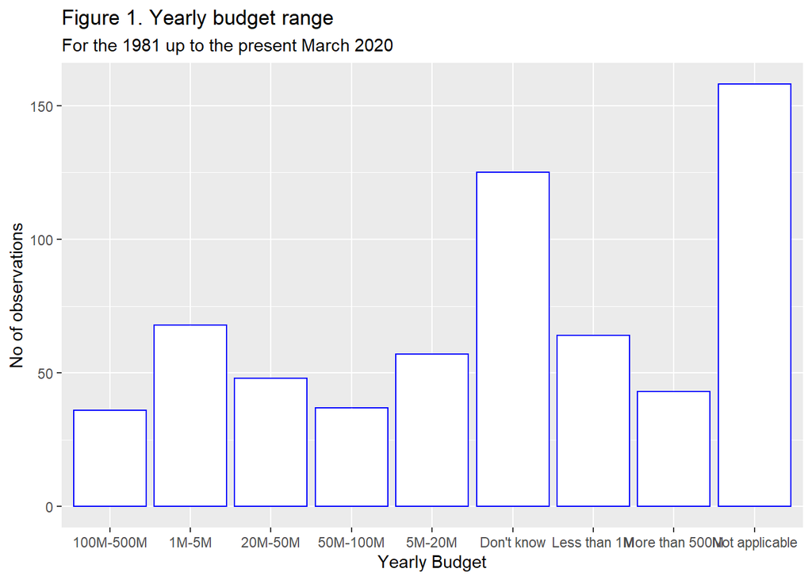

Within this point graph, we could see the increase of the interest in the IA policies and initiatives over the years, especially in 2019 where six non-member countries (Argentina, Brazil, Colombia, Costa Rica, Peru and Romania) adopted the Principles.

```
## # A tibble: 26 x 2
##    `Start date`     n
##           <dbl> <int>
##  1         2020    45
##  2         2019   272
##  3         2018   139
##  4         2017    46
##  5         2016    37
##  6         2015    17
##  7         2014    11
##  8         2013    10
##  9         2012     7
## 10         2011     6
## # ... with 16 more rows
```

[figure not shown]

This graph shows the concentration of the Policy instrument type category.

```
## # A tibble: 5 x 2
##   `Policy instrument type category`                     n
##   <chr>                                             <int>
## 1 Collaborative infrastructures (soft and physical)    89
## 2 Direct financial support                            144
## 3 Governance                                          330
## 4 Guidance, regulation and incentives                  69
## 5 Indirect financial support                            4
```

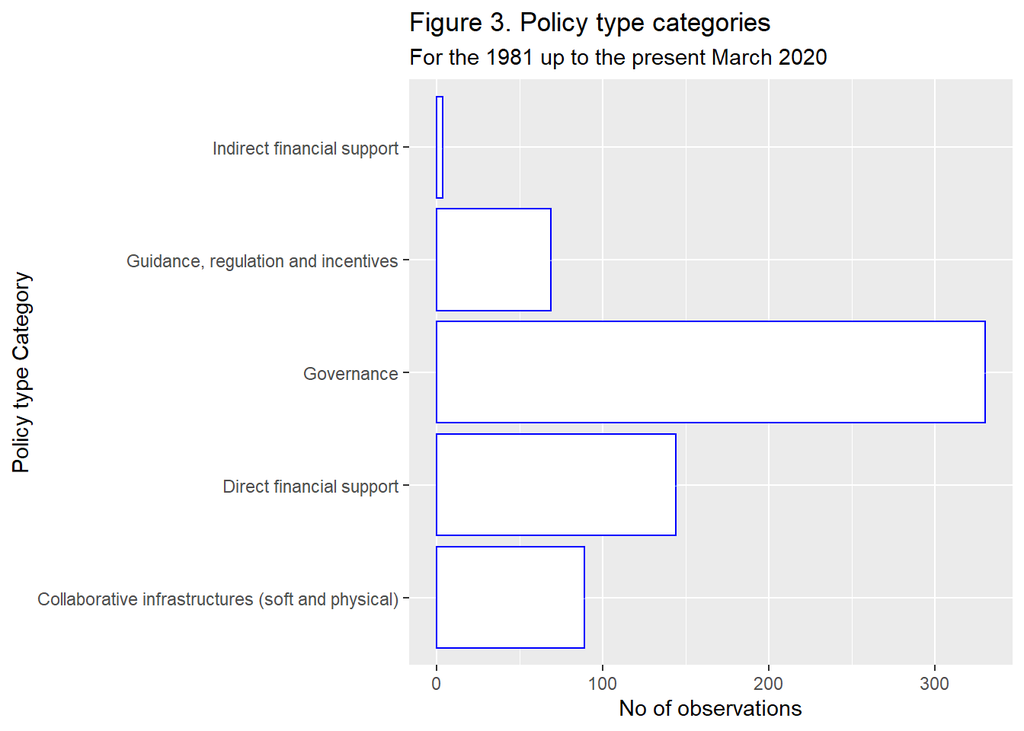

```
## # A tibble: 8 x 2
##   Country               n
##   <chr>             <int>
## 1 Canada               20
## 2 European Union       28
## 3 France               24
## 4 Germany              23
## 5 Republic of Korea    37
## 6 Serbia               23
## 7 United Kingdom       45
## 8 United States        70
```

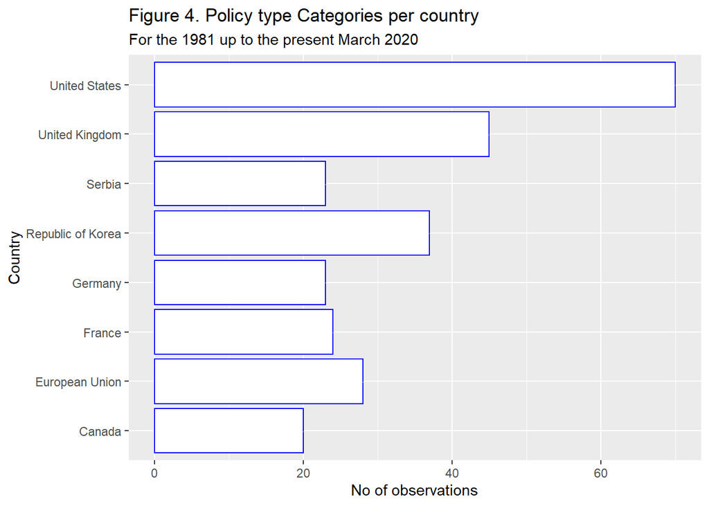

Here it is shown the proportion of evaluated policy initiatives:

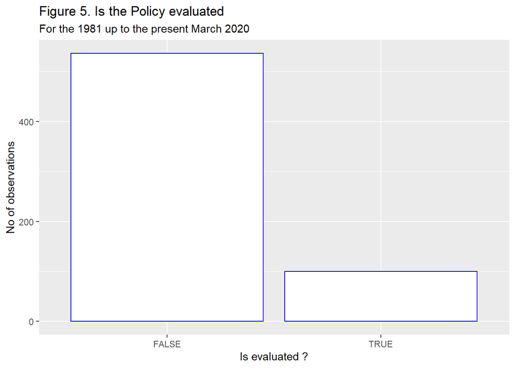

# 3 Model and Regression - Approach 1

## 3.1 Create a model

After analyzing the observations within the dataset, it is a noteworthy inscrease of the policy initatives implementation over the years as shown in Figure 2. and per country as shown in Figure 4. That being said, there have been more stakeholders (Target Groups) mostly government institutions that are interesting in the creation of policies and initiatives, as shown in Figure 3, for a variety of themes areas.

I consider that The relationship of the adoption of policies and initiatives per country depends on:  
* the increase of number of target groups that are interested in developing IA policy initiatives,  
* the addition of differnt themes related to AI

*I develop the following model based on two variables - Multiple Linear equation*:

$y$: *The relationship of the adoption* of policies and initiatives per country  
$beta_{0}$: Intercept  
$x_1$: Themes  
$x_2$: Target groups

$y = \beta_{0} + \beta_{1}x_1 + \beta_{2}x_2$

## 3.2 Running Regression

```
##
## Call:
## lm(formula = v13 ~ v15 + v18, data = new.set_)
##
## Residuals:
##     Min      1Q  Median      3Q     Max
## -34.632 -12.800  -1.078  16.584  36.038
##
## Coefficients:
##             Estimate Std. Error t value Pr(>|t|)
## (Intercept)  32.2862     1.5189  21.256  < 2e-16 ***
## v15          -1.1378     0.4315  -2.637  0.00858 **
## v18           0.6406     0.2101   3.049  0.00239 **
## ---
## Signif. codes:  0 '***' 0.001 '**' 0.01 '*' 0.05 '.' 0.1 ' ' 1
##
## Residual standard error: 17.66 on 633 degrees of freedom
## Multiple R-squared:  0.02391,    Adjusted R-squared:  0.02083
## F-statistic: 7.754 on 2 and 633 DF,  p-value: 0.0004709
```

By replacing the values obtained after running the mdoel, we got the following equation:

$y$: The relationship of the adoption of policies and initiatives per country  
$beta_{0}$: Intercept => 32.2862  
$x_1$: Themes => -1.1378  
$x_2$: Target groups => 06406

*$y = 32.2862 - 1.1378x_1 + 0.6406x_2$*

## 3.3 Statistical Analysis

### 3.3.1 Correlation

Here below it is shown the value of the *correlation* of the applied values within the model:  
Theorically when the correlation between the variables is weak, it suggests that the response variable is unexplained by the predictors. In other words, it means that there is a minimal relationship between the variables. This might be explained by the fact that v13 (dummy variable) that represents the different countries. *Even strong correlation still does not implyh causation*. Even if this model may show a meaningful nolinear relationship. *See the scatter figure below*, it may exist a relation between the growth of the initiative due to the increase of the themes and groups interested in AI policy and initiatives.

```
##             v13         v15        v18
## v13  1.00000000 -0.09787527 0.11486530
## v15 -0.09787527  1.00000000 0.04826775
## v18  0.11486530  0.04826775 1.00000000
```

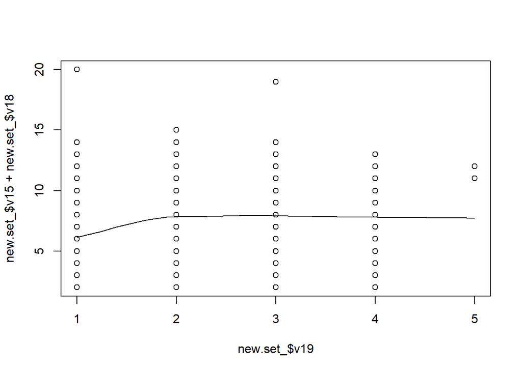

### 3.3.2 The p-Value

Theorically, it is considered a linear model to be statistically signicant only when both these p-Values are less than the pre-determined statistical signficance level (<0.05). As shown in the Summary *under the Coefficients* the p-value Pr(>|t|) for v15 = 0.00858 and v18 = 0.00239 and the *at the bottom* p-value_ is equal to 0.0004709.

# 4 Model and Regression - Approach 2

## 4.1 Create a model

After running my first model, I observed there is not a tight relationship/correlation between the number of the policy initatives implementation over the years per country and the stakeholders (Target Groups) the themes. I decided to create a new data set by *summarizing the Initiatives, Themes and Target Group by Year* as shown as follows:

```
## # A tibble: 26 x 4
##       v4 v19_No v18_No v15_No
##    <int>  <int>  <int>  <int>
##  1  1980      1      1      1
##  2  1981      4      4      1
##  3  1984      7     19     13
##  4  1986      9      9      8
##  5  1990      1      2      2
##  6  1991      4      5      7
##  7  1992      2      7      1
##  8  1995      2      2      2
##  9  1997      3      5      1
## 10  2000     12     46     32
## # ... with 16 more rows
```

```
##               v4    v19_No    v18_No    v15_No
## v4     1.0000000 0.4897412 0.5077510 0.4941198
## v19_No 0.4897412 1.0000000 0.9921967 0.9854508
## v18_No 0.5077510 0.9921967 1.0000000 0.9627075
## v15_No 0.4941198 0.9854508 0.9627075 1.0000000
```

So, my new model that the growth of the politicy and initiatives is depeding on:  
* the increase of *number of target groups* that are interested in developing IA policy initiatives,  
* the addition of *different/number of themes in AI*

*I develop the following model based on two variables - Multiple Linear equation*:

$y$: *The relationship of the number* of the adoption of policies and initiatives per country  
$beta_{0}$: Intercept  
$x_1$: No of Themes  
$x_2$: No of Target groups

$y = \beta_{0} + \beta_{1}x_1 + \beta_{2}x_2$

## 4.2 Running Regression

```
##
## Call:
## lm(formula = v19_No ~ v15_No + v18_No, data = m_)
##
## Residuals:
##     Min      1Q  Median      3Q     Max
## -14.429  -1.347   1.209   2.424   9.839
##
## Coefficients:
##             Estimate Std. Error t value Pr(>|t|)
## (Intercept)  -1.8094     1.3508  -1.339    0.193
## v15_No        0.4193     0.0431   9.729 1.28e-09 ***
## v18_No        0.2294     0.0164  13.986 9.82e-13 ***
## ---
## Signif. codes:  0 '***' 0.001 '**' 0.01 '*' 0.05 '.' 0.1 ' ' 1
##
## Residual standard error: 6.211 on 23 degrees of freedom
## Multiple R-squared:  0.997,  Adjusted R-squared:  0.9967
## F-statistic:  3772 on 2 and 23 DF,  p-value: < 2.2e-16
```

By replacing the values obtained after running the mdoel, we got the following equation:

$y$: The relationship of the number of the adoption of policies and initiatives per country  
$beta_{0}$: Intercept => -1.80942  
$x_1$: Themes => 0.4193  
$x_2$: Target groups => 0.2294

*$y = -1.80942 + 0.4193x_1 + 0.2294x_2$*

## 4.3 Statistical Analysis

### 4.3.1 Correlation

Here below it is shown the value of the correlation of the applied values within the model: Theorically when the correlation between the variables is High, it suggests that the response variable is explained by the predictors. In other words, it means that there is a high relationship between the variables. This new model show a meaningful linear relationship. *See the scatter figure below***. So, it exists a relation between the growth of the initiative due to the increase of the themes and groups interested in AI policy and initiatives.

```
##               v4    v19_No    v18_No    v15_No
## v4     1.0000000 0.4897412 0.5077510 0.4941198
## v19_No 0.4897412 1.0000000 0.9921967 0.9854508
## v18_No 0.5077510 0.9921967 1.0000000 0.9627075
## v15_No 0.4941198 0.9854508 0.9627075 1.0000000
```

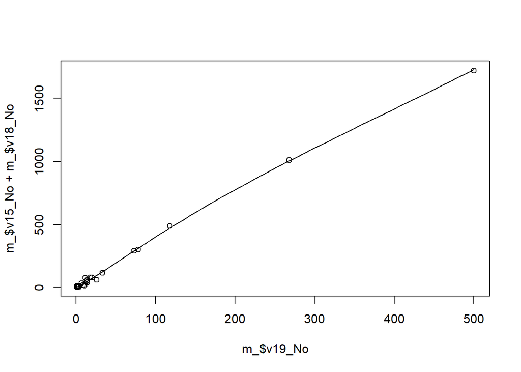

### 4.3.2 The p-Value

Theorically, it is considered a linear model to be statistically signicant only when both these p-Values are less than the pre-determined statistical signficance level (<0.05). As shown in the Summary under the Coefficients the p-value Pr(>|t|) for v15 = 1.28e-09 and v18 = 9.82e-13 and the at the bottom p-value_ is equal to 2.2e-16. We can imply that this model is *statistically significant or a fitted model*.

### 4.3.3 R-Squared

Theorically according to the result of the Multiple R-squared: 0.997 and Adjusted R-squared: 0.9967 (close to 1 or 100%) , it is considered that the variables of model do have a high degree of linear correlation which might be translated that the model is a good model or high goodness of fit.

# 5 Conclusion

By doing this assigment I have been glad to be able to have “my hand dirty” with a real situation where I have had to think, try, re-do, review the concepts and undestand the business context which I found the most important.

Following, I would provide a short insight of what I did for this assignment. Firstly, I browsed the OECD website to understand the business context. I learned the existance of this institution : *Organisation for Economic Co-operation and Development* and the valuable information/data we could obtain from it.

Secondly, by browsing the OECD website, I noticed I could obtain the datasets related to the 60 countries that belong to the AI Policy Observatory, and get the information about the 300 existing AI policy initiatives.

Third, I decided to do the assigment by using R Studio. I created some functions to get a unique dataset by reading every csv files I have downloaded from OECD Website and then, I ran some statistics to undestand the collected data.

After collecting the data about the AI policy initiatives, I applied EDA - Exploratory Data Analysis to handle with NA, missing values and some data transformation to create some dummy variables and remove some noise in the dataset.

Regarding the creation of the model, it was what I found very difficult since if the model is not right, applying any algorithm or technique- in this case Regression - is completely useless. After analysing the data, my first move was to find the relationship between the initiatives and the number of target groups and themes. In my opinion, it would be more AI policy initiatives created as long as there are more stakeholders interested in AI and for a variety of Themes. In short, I found a low correlation for the first model *y = 32.2862 − 1.1378x1 + 0.6406x2*  
*y : The relationship of the **adoption of policies** and initiatives per country where x1 represents the Themes and and x2 the Target groups*

The different results for the Adjusted R-squared, p-value, Pr(>|t|) and Correlation states the weakness of the model and the poor relation between the variables.

Then, I uploaded the dataset in RapidMiner trying to get a different overview or insight of the problem. RapidMini showed the that Target Group and Themes are variable that had a hight importance within the dataet. So, I could figure out a new model by changing the dataset. I grouped the number of the type of policy per year and calculating the sum of the number of the Themes and Target Groups. I got the following new model: *y = −1.80942 + 0.4193x1 + 0.2294x2* *y : The relationship of the **number of the adoption** of policies and initiatives per country where x1 represents the Themes and and x2 the Target groups*

The different results for the Adjusted R-squared, p-value, Pr(>|t|) and Correlation states the strengh of the model and the high relation between the variables.

Finally, due to the small size of the dataset, it does not makes any sense to apply Regression for prediction within the context of Machine Learning.